Name: Chao Li  
Email: chaoli930712@gmail.com

# I. Introduction

The objective of this data challenge is to build machine learning models to predict the conversion probability for each loan offer. The dataset provided is a sample of the offers that users have clicked on in the past including information on both the lead (e.g., the user's self-report credit rating, income, etc) and the offers that they clicked on (e.g., the loan amount offered, APR, etc).

The project will be described as follows:

1. Data cleaning and exploratory data analysis
2. Building machine learning models
3. Further model improvement with autoencoder
4. Conclusion

```python
#load modules
import os
import time
from keras.layers import Input, Dense
from keras.models import Model, Sequential
from keras import regularizers
from keras import losses

from sklearn.preprocessing import LabelEncoder, OneHotEncoder,MinMaxScaler
from sklearn.preprocessing import StandardScaler
from sklearn.model_selection import train_test_split
from sklearn.linear_model import LogisticRegression
from sklearn.svm import SVC
from sklearn.neighbors import KNeighborsClassifier
from sklearn.tree import DecisionTreeClassifier
from sklearn.ensemble import RandomForestClassifier
from sklearn.metrics import classification_report, accuracy_score, confusion_matrix
from sklearn import preprocessing
from sklearn.manifold import TSNE
from sklearn.decomposition import PCA, TruncatedSVD
from sklearn.model_selection import GridSearchCV,RandomizedSearchCV

import lightgbm as lgb
from imblearn.over_sampling import SMOTE

from scipy.stats import randint as sp_randint
from scipy.stats import randint as sp_uniform

import matplotlib.pyplot as plt
import matplotlib.patches as mpatches
import matplotlib.gridspec as gridspec
import pandas as pd
import numpy as np
import seaborn as sns
sns.set(style="whitegrid")
np.random.seed(203)

import pandas_profiling as pp

import warnings
warnings.filterwarnings('ignore')
```

```python
#load dataset
df = pd.read_csv('ds_take_home_dataset.csv')
print ('There are {} rows and {} columns in the dataset'.format(*df.shape))
df.head(3)
```

```
There are 141915 rows and 21 columns in the dataset
```

|  | offer_id | rate_table_id | lead_created_at | lender_id | apr | offered_amount | term_length | term_unit | monthly_payment | lead_uuid | ... | company_uuid | credit_rating | loan_purpose | requested_amount | income | state | traffic_source | click_id | is_funded | is_mobile |
| --- | --- | --- | --- | --- | --- | --- | --- | --- | --- | --- | --- | --- | --- | --- | --- | --- | --- | --- | --- | --- | --- |
| 0 | 1495765590 | 274688181 | 2019-03-05T04:19:43Z | 1 | 27.950 | 16500 | 36 | month | 649.67 | 395590827986471346 | ... | 3973050536950353272 | good | debt_consolidation | 15000.0 | 80000.0 | NH | 3090 | 812737593 | f | True |
| 1 | 1510816161 | 278645454 | 2019-03-12T19:47:31Z | 2 | 148.238 | 1300 | 24 | month | 176.37 | 2887757516335649345 | ... | 8484512372439812541 | fair | auto | 40000.0 | 62000.0 | VA | 1452 | 812887023 | f | True |
| 2 | 1556028699 | 295675917 | 2019-04-22T09:15:27Z | 3 | 29.500 | 19200 | 24 | month | 1015.03 | 3424475664079068159 | ... | 3973050536950353272 | good | debt_consolidation | 25000.0 | 55000.0 | CA | 3090 | 813691164 | f | True |

3 rows × 21 columns

```python
# where to save figures and results
ROOT_DIR = os.path.dirname(os.path.realpath('__file__'))
Image_Path = os.path.join(ROOT_DIR,'Images')

if not os.path.exists('Images'):
    os.makedirs('Images')
Image_path = os.path.join('Images')

def save_fig(fig_id, tight_layout=True):
    path = os.path.join(Image_path,fig_id + ".png")
    if tight_layout:
        plt.tight_layout()
    plt.savefig(path, format='png', dpi=300)
```

# II. Data cleaning and Exploratory data analysis

Overview

Dataset info

| Number of variables | 21 |
| --- | --- |
| Number of observations | 141915 |
| Total Missing (%) | 2.7% |
| Total size in memory | 22.7 MiB |
| Average record size in memory | 168.0 B |

Variables types

| Numeric | 10 |
| --- | --- |
| Categorical | 7 |
| Boolean | 0 |
| Date | 0 |
| Text (Unique) | 0 |
| Rejected | 3 |
| Unsupported | 1 |

Warnings

- `rate_table_id` is highly correlated with `offer_id` (ρ = 0.99769) Rejected

- `lead_created_at` has a high cardinality: 139413 distinct values Warning

- `monthly_payment` is highly correlated with `offered_amount` (ρ = 0.92212) Rejected

- `rate_table_created_at` has a high cardinality: 138545 distinct values Warning

- `requested_amount` is highly skewed (γ1 = 192.23) Skewed

- `income` has 2298 / 1.6% missing values Missing

- `income` is highly skewed (γ1 = 212.78) Skewed

- `state` has a high cardinality: 53 distinct values Warning

- `click_id` is highly correlated with `rate_table_id` (ρ = 0.99737) Rejected

- `is_mobile` has 78684 / 55.4% missing values Missing

- `is_mobile` is an unsupported type, check if it needs cleaning or further analysis Warning

- Dataset has 1 duplicate rows Warning

Variables

offer_id  
Numeric

| Distinct count | 141914 |
| --- | --- |
| Unique (%) | 100.0% |
| Missing (%) | 0.0% |
| Missing (n) | 0 |
| Infinite (%) | 0.0% |
| Infinite (n) | 0 |

| Mean | 1555900000 |
| --- | --- |
| Minimum | 1491439239 |
| Maximum | 1603020393 |
| Zeros (%) | 0.0% |

Toggle details

**Statistics**

Quantile statistics

| Minimum | 1491439239 |
| --- | --- |
| 5-th percentile | 1501400000 |
| Q1 | 1535200000 |
| Median | 1557100000 |
| Q3 | 1582000000 |
| 95-th percentile | 1598800000 |
| Maximum | 1603020393 |
| Range | 111581154 |
| Interquartile range | 46834000 |

Descriptive statistics

| Standard deviation | 29410000 |
| --- | --- |
| Coef of variation | 0.018902 |
| Kurtosis | -0.88474 |
| Mean | 1555900000 |
| MAD | 24982000 |
| Skewness | -0.27284 |
| Sum | 220810670574153 |
| Variance | 864930000000000 |
| Memory size | 1.1 MiB |

**Histogram**

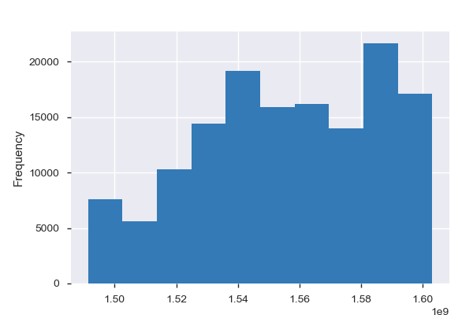

**Common Values**

| Value | Count | Frequency (%) |  |
| --- | --- | --- | --- |
| 1601695245 | 2 | 0.0% |  |
| 1535641599 | 1 | 0.0% |  |
| 1556567232 | 1 | 0.0% |  |
| 1590394053 | 1 | 0.0% |  |
| 1595897028 | 1 | 0.0% |  |
| 1559448771 | 1 | 0.0% |  |
| 1584612546 | 1 | 0.0% |  |
| 1536908481 | 1 | 0.0% |  |
| 1561109694 | 1 | 0.0% |  |
| 1511984331 | 1 | 0.0% |  |
| Other values (141904) | 141904 | 100.0% |  |

**Extreme Values**

Minimum 5 values

| Value | Count | Frequency (%) |  |
| --- | --- | --- | --- |
| 1491439239 | 1 | 0.0% |  |
| 1491439791 | 1 | 0.0% |  |
| 1491440784 | 1 | 0.0% |  |
| 1491440883 | 1 | 0.0% |  |
| 1491441264 | 1 | 0.0% |  |

Maximum 5 values

| Value | Count | Frequency (%) |  |
| --- | --- | --- | --- |
| 1603018323 | 1 | 0.0% |  |
| 1603018707 | 1 | 0.0% |  |
| 1603019052 | 1 | 0.0% |  |
| 1603019760 | 1 | 0.0% |  |
| 1603020393 | 1 | 0.0% |  |

rate_table_id  
Highly correlated

*This variable is highly correlated with `offer_id` and should be ignored for analysis*

| Correlation | 0.99769 |
| --- | --- |

lead_created_at  
Categorical

| Distinct count | 139413 |
| --- | --- |
| Unique (%) | 98.2% |
| Missing (%) | 0.0% |
| Missing (n) | 0 |

| 2019-04-26T21:32:48Z | 10 |
| --- | --- |
| 2019-04-04T05:59:18Z | 5 |
| 2019-05-09T16:08:42Z | 5 |
| Other values (139410) | 141895 |

Toggle details

| Value | Count | Frequency (%) |  |
| --- | --- | --- | --- |
| 2019-04-26T21:32:48Z | 10 | 0.0% |  |
| 2019-04-04T05:59:18Z | 5 | 0.0% |  |
| 2019-05-09T16:08:42Z | 5 | 0.0% |  |
| 2019-04-28T01:52:01Z | 4 | 0.0% |  |
| 2019-04-06T23:39:18Z | 4 | 0.0% |  |
| 2019-05-06T03:08:47Z | 4 | 0.0% |  |
| 2019-04-26T19:19:04Z | 4 | 0.0% |  |
| 2019-04-26T20:22:27Z | 3 | 0.0% |  |
| 2019-04-23T19:38:08Z | 3 | 0.0% |  |
| 2019-03-06T01:25:52Z | 3 | 0.0% |  |
| Other values (139403) | 141870 | 100.0% |  |

lender_id  
Numeric

| Distinct count | 20 |
| --- | --- |
| Unique (%) | 0.0% |
| Missing (%) | 0.0% |
| Missing (n) | 0 |
| Infinite (%) | 0.0% |
| Infinite (n) | 0 |

| Mean | 5.6553 |
| --- | --- |
| Minimum | 1 |
| Maximum | 20 |
| Zeros (%) | 0.0% |

Toggle details

**Statistics**

Quantile statistics

| Minimum | 1 |
| --- | --- |
| 5-th percentile | 1 |
| Q1 | 2 |
| Median | 5 |
| Q3 | 8 |
| 95-th percentile | 14 |
| Maximum | 20 |
| Range | 19 |
| Interquartile range | 6 |

Descriptive statistics

| Standard deviation | 3.7877 |
| --- | --- |
| Coef of variation | 0.66977 |
| Kurtosis | 0.80355 |
| Mean | 5.6553 |
| MAD | 3.014 |
| Skewness | 1.0841 |
| Sum | 802566 |
| Variance | 14.347 |
| Memory size | 1.1 MiB |

**Histogram**

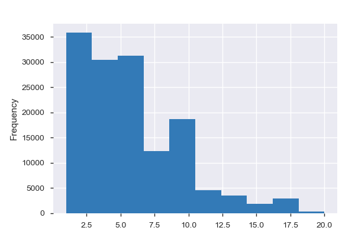

**Common Values**

| Value | Count | Frequency (%) |  |
| --- | --- | --- | --- |
| 5 | 28231 | 19.9% |  |
| 4 | 27225 | 19.2% |  |
| 2 | 25031 | 17.6% |  |
| 10 | 14461 | 10.2% |  |
| 1 | 10785 | 7.6% |  |
| 8 | 9465 | 6.7% |  |
| 9 | 4263 | 3.0% |  |
| 3 | 3239 | 2.3% |  |
| 6 | 3046 | 2.1% |  |
| 11 | 2988 | 2.1% |  |
| Other values (10) | 13181 | 9.3% |  |

**Extreme Values**

Minimum 5 values

| Value | Count | Frequency (%) |  |
| --- | --- | --- | --- |
| 1 | 10785 | 7.6% |  |
| 2 | 25031 | 17.6% |  |
| 3 | 3239 | 2.3% |  |
| 4 | 27225 | 19.2% |  |
| 5 | 28231 | 19.9% |  |

Maximum 5 values

| Value | Count | Frequency (%) |  |
| --- | --- | --- | --- |
| 16 | 80 | 0.1% |  |
| 17 | 2425 | 1.7% |  |
| 18 | 463 | 0.3% |  |
| 19 | 225 | 0.2% |  |
| 20 | 71 | 0.1% |  |

apr  
Numeric

| Distinct count | 7815 |
| --- | --- |
| Unique (%) | 5.5% |
| Missing (%) | 0.0% |
| Missing (n) | 0 |
| Infinite (%) | 0.0% |
| Infinite (n) | 0 |

| Mean | 50.038 |
| --- | --- |
| Minimum | 4.29 |
| Maximum | 365 |
| Zeros (%) | 0.0% |

Toggle details

**Statistics**

Quantile statistics

| Minimum | 4.29 |
| --- | --- |
| 5-th percentile | 9.5694 |
| Q1 | 19.95 |
| Median | 29.49 |
| Q3 | 58.722 |
| 95-th percentile | 159.99 |
| Maximum | 365 |
| Range | 360.71 |
| Interquartile range | 38.772 |

Descriptive statistics

| Standard deviation | 50.417 |
| --- | --- |
| Coef of variation | 1.0076 |
| Kurtosis | 2.7061 |
| Mean | 50.038 |
| MAD | 38.236 |
| Skewness | 1.7874 |
| Sum | 7101200 |
| Variance | 2541.8 |
| Memory size | 1.1 MiB |

**Histogram**

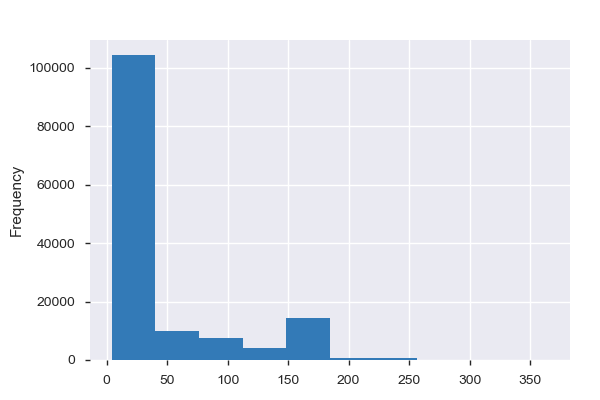

**Common Values**

| Value | Count | Frequency (%) |  |
| --- | --- | --- | --- |
| 35.99 | 9038 | 6.4% |  |
| 159.99 | 8840 | 6.2% |  |
| 35.95 | 4204 | 3.0% |  |
| 25.0 | 2369 | 1.7% |  |
| 35.88800000000001 | 1880 | 1.3% |  |
| 36.0 | 1731 | 1.2% |  |
| 19.95 | 1569 | 1.1% |  |
| 27.95 | 1569 | 1.1% |  |
| 25.95 | 1527 | 1.1% |  |
| 8.1729 | 1521 | 1.1% |  |
| Other values (7805) | 107667 | 75.9% |  |

**Extreme Values**

Minimum 5 values

| Value | Count | Frequency (%) |  |
| --- | --- | --- | --- |
| 4.29 | 1 | 0.0% |  |
| 4.54 | 2 | 0.0% |  |
| 4.99 | 25 | 0.0% |  |
| 5.34 | 4 | 0.0% |  |
| 5.73 | 3 | 0.0% |  |

Maximum 5 values

| Value | Count | Frequency (%) |  |
| --- | --- | --- | --- |
| 249.0 | 666 | 0.5% |  |
| 295.0 | 56 | 0.0% |  |
| 299.0 | 111 | 0.1% |  |
| 350.0 | 58 | 0.0% |  |
| 365.0 | 32 | 0.0% |  |

offered_amount  
Numeric

| Distinct count | 1971 |
| --- | --- |
| Unique (%) | 1.4% |
| Missing (%) | 0.0% |
| Missing (n) | 0 |
| Infinite (%) | 0.0% |
| Infinite (n) | 0 |

| Mean | 11956 |
| --- | --- |
| Minimum | 300 |
| Maximum | 100000 |
| Zeros (%) | 0.0% |

Toggle details

**Statistics**

Quantile statistics

| Minimum | 300 |
| --- | --- |
| 5-th percentile | 1000 |
| Q1 | 2600 |
| Median | 8000 |
| Q3 | 17000 |
| 95-th percentile | 35000 |
| Maximum | 100000 |
| Range | 99700 |
| Interquartile range | 14400 |

Descriptive statistics

| Standard deviation | 12383 |
| --- | --- |
| Coef of variation | 1.0357 |
| Kurtosis | 7.9773 |
| Mean | 11956 |
| MAD | 9365.2 |
| Skewness | 2.1033 |
| Sum | 1696793989 |
| Variance | 153350000 |
| Memory size | 1.1 MiB |

**Histogram**

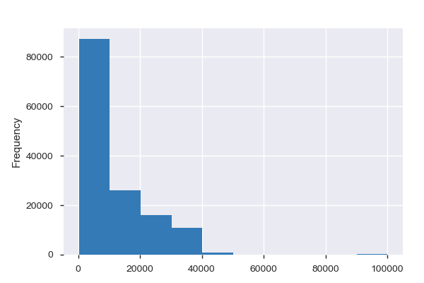

**Common Values**

| Value | Count | Frequency (%) |  |
| --- | --- | --- | --- |
| 1500 | 8012 | 5.6% |  |
| 2000 | 7636 | 5.4% |  |
| 1000 | 7561 | 5.3% |  |
| 10000 | 6083 | 4.3% |  |
| 25000 | 5255 | 3.7% |  |
| 15000 | 4177 | 2.9% |  |
| 35000 | 4163 | 2.9% |  |
| 5000 | 4057 | 2.9% |  |
| 40000 | 3975 | 2.8% |  |
| 8000 | 3407 | 2.4% |  |
| Other values (1961) | 87589 | 61.7% |  |

**Extreme Values**

Minimum 5 values

| Value | Count | Frequency (%) |  |
| --- | --- | --- | --- |
| 300 | 17 | 0.0% |  |
| 350 | 2 | 0.0% |  |
| 400 | 2 | 0.0% |  |
| 500 | 50 | 0.0% |  |
| 600 | 69 | 0.0% |  |

Maximum 5 values

| Value | Count | Frequency (%) |  |
| --- | --- | --- | --- |
| 97500 | 69 | 0.0% |  |
| 98054 | 1 | 0.0% |  |
| 99906 | 1 | 0.0% |  |
| 99999 | 2 | 0.0% |  |
| 100000 | 324 | 0.2% |  |

term_length  
Numeric

| Distinct count | 20 |
| --- | --- |
| Unique (%) | 0.0% |
| Missing (%) | 0.0% |
| Missing (n) | 0 |
| Infinite (%) | 0.0% |
| Infinite (n) | 0 |

| Mean | 32.845 |
| --- | --- |
| Minimum | 3 |
| Maximum | 180 |
| Zeros (%) | 0.0% |

Toggle details

**Statistics**

Quantile statistics

| Minimum | 3 |
| --- | --- |
| 5-th percentile | 3 |
| Q1 | 24 |
| Median | 36 |
| Q3 | 36 |
| 95-th percentile | 60 |
| Maximum | 180 |
| Range | 177 |
| Interquartile range | 12 |

Descriptive statistics

| Standard deviation | 17.524 |
| --- | --- |
| Coef of variation | 0.53354 |
| Kurtosis | -0.050442 |
| Mean | 32.845 |
| MAD | 13.476 |
| Skewness | 0.11403 |
| Sum | 4661247 |
| Variance | 307.11 |
| Memory size | 1.1 MiB |

**Histogram**

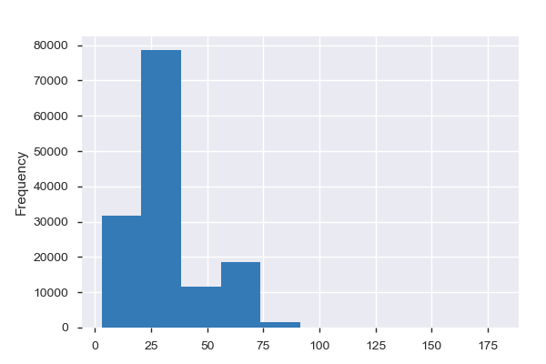

**Common Values**

| Value | Count | Frequency (%) |  |
| --- | --- | --- | --- |
| 36 | 61181 | 43.1% |  |
| 60 | 18212 | 12.8% |  |
| 24 | 17102 | 12.1% |  |
| 48 | 11578 | 8.2% |  |
| 3 | 11392 | 8.0% |  |
| 10 | 9392 | 6.6% |  |
| 12 | 7495 | 5.3% |  |
| 5 | 3069 | 2.2% |  |
| 84 | 1459 | 1.0% |  |
| 72 | 420 | 0.3% |  |
| Other values (10) | 615 | 0.4% |  |

**Extreme Values**

Minimum 5 values

| Value | Count | Frequency (%) |  |
| --- | --- | --- | --- |
| 3 | 11392 | 8.0% |  |
| 4 | 44 | 0.0% |  |
| 5 | 3069 | 2.2% |  |
| 6 | 33 | 0.0% |  |
| 7 | 111 | 0.1% |  |

Maximum 5 values

| Value | Count | Frequency (%) |  |
| --- | --- | --- | --- |
| 60 | 18212 | 12.8% |  |
| 72 | 420 | 0.3% |  |
| 84 | 1459 | 1.0% |  |
| 120 | 18 | 0.0% |  |
| 180 | 4 | 0.0% |  |

term_unit  
Categorical

| Distinct count | 3 |
| --- | --- |
| Unique (%) | 0.0% |
| Missing (%) | 0.0% |
| Missing (n) | 0 |

| month | 124560 |
| --- | --- |
| year | 14461 |
| day | 2894 |

Toggle details

| Value | Count | Frequency (%) |  |
| --- | --- | --- | --- |
| month | 124560 | 87.8% |  |
| year | 14461 | 10.2% |  |
| day | 2894 | 2.0% |  |

monthly_payment  
Highly correlated

*This variable is highly correlated with `offered_amount` and should be ignored for analysis*

| Correlation | 0.92212 |
| --- | --- |

lead_uuid  
Numeric

| Distinct count | 140300 |
| --- | --- |
| Unique (%) | 98.9% |
| Missing (%) | 0.0% |
| Missing (n) | 0 |
| Infinite (%) | 0.0% |
| Infinite (n) | 0 |

| Mean | 7893300000000000 |
| --- | --- |
| Minimum | -9223304160201085154 |
| Maximum | 9223269764882563005 |
| Zeros (%) | 0.0% |

Toggle details

**Statistics**

Quantile statistics

| Minimum | -9223304160201085154 |
| --- | --- |
| 5-th percentile | -8.2951e+18 |
| Q1 | -4.6163e+18 |
| Median | 1.3794e+16 |
| Q3 | 4.6235e+18 |
| 95-th percentile | 8.3216e+18 |
| Maximum | 9223269764882563005 |
| Range | -170148625903457 |
| Interquartile range | 9.2398e+18 |

Descriptive statistics

| Standard deviation | 5.3312e+18 |
| --- | --- |
| Coef of variation | 675.41 |
| Kurtosis | -1.2001 |
| Mean | 7893300000000000 |
| MAD | 4.6168e+18 |
| Skewness | -0.00019248 |
| Sum | -5077297016908907569 |
| Variance | 2.8422e+37 |
| Memory size | 1.1 MiB |

**Histogram**

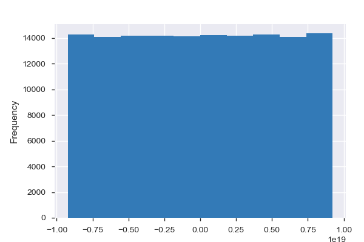

**Common Values**

| Value | Count | Frequency (%) |  |
| --- | --- | --- | --- |
| 9099291656783223344 | 10 | 0.0% |  |
| 4483853117847051151 | 5 | 0.0% |  |
| 1827393959854964680 | 5 | 0.0% |  |
| -8148906831698472926 | 5 | 0.0% |  |
| -8637041995690715264 | 4 | 0.0% |  |
| -7857998921640481542 | 4 | 0.0% |  |
| -8383762084565809207 | 4 | 0.0% |  |
| -3585223287891754802 | 4 | 0.0% |  |
| 197523327011951267 | 4 | 0.0% |  |
| -2577575517967467030 | 4 | 0.0% |  |
| Other values (140290) | 141866 | 100.0% |  |

**Extreme Values**

Minimum 5 values

| Value | Count | Frequency (%) |  |
| --- | --- | --- | --- |
| -9223304160201085154 | 1 | 0.0% |  |
| -9223144860545507459 | 1 | 0.0% |  |
| -9223071589016516549 | 1 | 0.0% |  |
| -9222751491737911492 | 1 | 0.0% |  |
| -9222650304495197164 | 1 | 0.0% |  |

Maximum 5 values

| Value | Count | Frequency (%) |  |
| --- | --- | --- | --- |
| 9222477520206109952 | 1 | 0.0% |  |
| 9222500708058271358 | 1 | 0.0% |  |
| 9222836565530064362 | 1 | 0.0% |  |
| 9223220555010012530 | 1 | 0.0% |  |
| 9223269764882563005 | 1 | 0.0% |  |

rate_table_created_at  
Categorical

| Distinct count | 138545 |
| --- | --- |
| Unique (%) | 97.6% |
| Missing (%) | 0.0% |
| Missing (n) | 0 |

| 2019-04-26T21:32:47Z | 10 |
| --- | --- |
| 2019-05-09T16:08:37Z | 5 |
| 2019-04-04T05:59:17Z | 5 |
| Other values (138542) | 141895 |

Toggle details

| Value | Count | Frequency (%) |  |
| --- | --- | --- | --- |
| 2019-04-26T21:32:47Z | 10 | 0.0% |  |
| 2019-05-09T16:08:37Z | 5 | 0.0% |  |
| 2019-04-04T05:59:17Z | 5 | 0.0% |  |
| 2019-03-05T16:43:34Z | 5 | 0.0% |  |
| 2019-05-09T17:06:12Z | 4 | 0.0% |  |
| 2019-05-13T18:05:28Z | 4 | 0.0% |  |
| 2019-05-01T20:25:51Z | 4 | 0.0% |  |
| 2019-05-15T04:01:52Z | 4 | 0.0% |  |
| 2019-04-28T01:52:01Z | 4 | 0.0% |  |
| 2019-04-22T01:41:59Z | 4 | 0.0% |  |
| Other values (138535) | 141866 | 100.0% |  |

company_uuid  
Numeric

| Distinct count | 176 |
| --- | --- |
| Unique (%) | 0.1% |
| Missing (%) | 0.0% |
| Missing (n) | 0 |
| Infinite (%) | 0.0% |
| Infinite (n) | 0 |

| Mean | 6.9422e+17 |
| --- | --- |
| Minimum | -9214333630574069643 |
| Maximum | 9030886670875391779 |
| Zeros (%) | 0.0% |

Toggle details

**Statistics**

Quantile statistics

| Minimum | -9214333630574069643 |
| --- | --- |
| 5-th percentile | -7.7674e+18 |
| Q1 | -4.633e+18 |
| Median | 2.454e+18 |
| Q3 | 3.9731e+18 |
| 95-th percentile | 8.4845e+18 |
| Maximum | 9030886670875391779 |
| Range | -201523772260090194 |
| Interquartile range | 8.6061e+18 |

Descriptive statistics

| Standard deviation | 4.8275e+18 |
| --- | --- |
| Coef of variation | 6.9539 |
| Kurtosis | -1.0887 |
| Mean | 6.9422e+17 |
| MAD | 4.1976e+18 |
| Skewness | -0.29476 |
| Sum | -3718421350872096740 |
| Variance | 2.3305e+37 |
| Memory size | 1.1 MiB |

**Histogram**

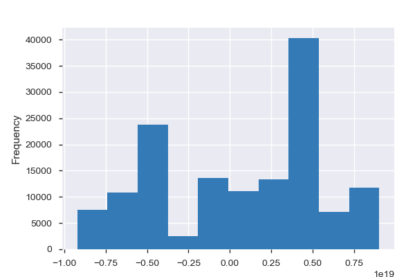

**Common Values**

| Value | Count | Frequency (%) |  |
| --- | --- | --- | --- |
| 3973050536950353272 | 36529 | 25.7% |  |
| -4633008154237388280 | 18106 | 12.8% |  |
| -287173439723278177 | 7841 | 5.5% |  |
| 3242147885092572777 | 7731 | 5.4% |  |
| 8484512372439812541 | 7462 | 5.3% |  |
| -6219741992897481971 | 7268 | 5.1% |  |
| 586116806865046934 | 6952 | 4.9% |  |
| 3260694297778322767 | 3198 | 2.3% |  |
| 6647218035453046888 | 3042 | 2.1% |  |
| -7767350052406295239 | 2928 | 2.1% |  |
| Other values (166) | 40858 | 28.8% |  |

**Extreme Values**

Minimum 5 values

| Value | Count | Frequency (%) |  |
| --- | --- | --- | --- |
| -9214333630574069643 | 81 | 0.1% |  |
| -9208103008961821897 | 287 | 0.2% |  |
| -9106509954156519060 | 489 | 0.3% |  |
| -9036306627472720057 | 2 | 0.0% |  |
| -9020365261503487089 | 72 | 0.1% |  |

Maximum 5 values

| Value | Count | Frequency (%) |  |
| --- | --- | --- | --- |
| 8615685976836064411 | 1141 | 0.8% |  |
| 8650173082048235050 | 1 | 0.0% |  |
| 8689556975656053656 | 75 | 0.1% |  |
| 8813555200441307144 | 40 | 0.0% |  |
| 9030886670875391779 | 2 | 0.0% |  |

credit_rating  
Categorical

| Distinct count | 6 |
| --- | --- |
| Unique (%) | 0.0% |
| Missing (%) | 0.0% |
| Missing (n) | 53 |

| good | 56910 |
| --- | --- |
| fair | 47116 |
| poor | 19031 |
| Other values (2) | 18805 |

Toggle details

| Value | Count | Frequency (%) |  |
| --- | --- | --- | --- |
| good | 56910 | 40.1% |  |
| fair | 47116 | 33.2% |  |
| poor | 19031 | 13.4% |  |
| excellent | 18801 | 13.2% |  |
| unknown | 4 | 0.0% |  |
| (Missing) | 53 | 0.0% |  |

loan_purpose  
Categorical

| Distinct count | 21 |
| --- | --- |
| Unique (%) | 0.0% |
| Missing (%) | 0.0% |
| Missing (n) | 39 |

| debt_consolidation | 103914 |
| --- | --- |
| other | 12807 |
| home_improvement | 7184 |
| Other values (17) | 17971 |

Toggle details

| Value | Count | Frequency (%) |  |
| --- | --- | --- | --- |
| debt_consolidation | 103914 | 73.2% |  |
| other | 12807 | 9.0% |  |
| home_improvement | 7184 | 5.1% |  |
| auto | 3904 | 2.8% |  |
| large_purchases | 2600 | 1.8% |  |
| medical_dental | 2430 | 1.7% |  |
| credit_card_refi | 1936 | 1.4% |  |
| business | 1464 | 1.0% |  |
| wedding | 1342 | 0.9% |  |
| vacation | 974 | 0.7% |  |
| Other values (10) | 3321 | 2.3% |  |

requested_amount  
Numeric

| Distinct count | 1591 |
| --- | --- |
| Unique (%) | 1.1% |
| Missing (%) | 0.0% |
| Missing (n) | 10 |
| Infinite (%) | 0.0% |
| Infinite (n) | 0 |

| Mean | 18340 |
| --- | --- |
| Minimum | 2 |
| Maximum | 10000000 |
| Zeros (%) | 0.0% |

Toggle details

**Statistics**

Quantile statistics

| Minimum | 2 |
| --- | --- |
| 5-th percentile | 1000 |
| Q1 | 5000 |
| Median | 10000 |
| Q3 | 25000 |
| 95-th percentile | 50000 |
| Maximum | 10000000 |
| Range | 10000000 |
| Interquartile range | 20000 |

Descriptive statistics

| Standard deviation | 33198 |
| --- | --- |
| Coef of variation | 1.8102 |
| Kurtosis | 57597 |
| Mean | 18340 |
| MAD | 14347 |
| Skewness | 192.23 |
| Sum | 2602500000 |
| Variance | 1102100000 |
| Memory size | 1.1 MiB |

**Histogram**

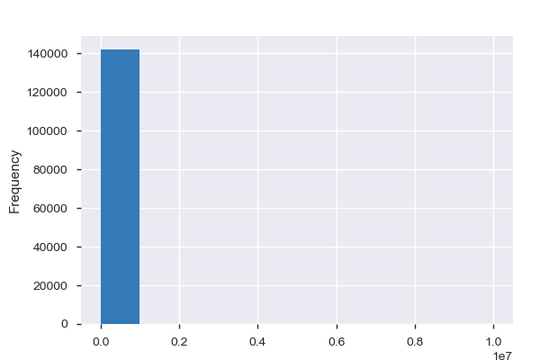

**Common Values**

| Value | Count | Frequency (%) |  |
| --- | --- | --- | --- |
| 5000.0 | 19357 | 13.6% |  |
| 10000.0 | 13571 | 9.6% |  |
| 20000.0 | 9585 | 6.8% |  |
| 15000.0 | 8731 | 6.2% |  |
| 1000.0 | 7114 | 5.0% |  |
| 25000.0 | 7077 | 5.0% |  |
| 50000.0 | 6241 | 4.4% |  |
| 30000.0 | 5800 | 4.1% |  |
| 2500.0 | 4670 | 3.3% |  |
| 40000.0 | 4366 | 3.1% |  |
| Other values (1580) | 55393 | 39.0% |  |

**Extreme Values**

Minimum 5 values

| Value | Count | Frequency (%) |  |
| --- | --- | --- | --- |
| 2.0 | 3 | 0.0% |  |
| 6.0 | 1 | 0.0% |  |
| 10.0 | 3 | 0.0% |  |
| 13.0 | 2 | 0.0% |  |
| 15.0 | 2 | 0.0% |  |

Maximum 5 values

| Value | Count | Frequency (%) |  |
| --- | --- | --- | --- |
| 400008.0 | 1 | 0.0% |  |
| 499999.0 | 1 | 0.0% |  |
| 500000.0 | 1 | 0.0% |  |
| 1000000.0 | 1 | 0.0% |  |
| 10000000.0 | 1 | 0.0% |  |

income  
Numeric

| Distinct count | 7146 |
| --- | --- |
| Unique (%) | 5.0% |
| Missing (%) | 1.6% |
| Missing (n) | 2298 |
| Infinite (%) | 0.0% |
| Infinite (n) | 0 |

| Mean | 79066 |
| --- | --- |
| Minimum | 0 |
| Maximum | 114000000 |
| Zeros (%) | 0.0% |

Toggle details

**Statistics**

Quantile statistics

| Minimum | 0 |
| --- | --- |
| 5-th percentile | 25000 |
| Q1 | 40000 |
| Median | 60000 |
| Q3 | 85000 |
| 95-th percentile | 160000 |
| Maximum | 114000000 |
| Range | 114000000 |
| Interquartile range | 45000 |

Descriptive statistics

| Standard deviation | 373610 |
| --- | --- |
| Coef of variation | 4.7253 |
| Kurtosis | 62396 |
| Mean | 79066 |
| MAD | 43623 |
| Skewness | 212.78 |
| Sum | 11039000000 |
| Variance | 139590000000 |
| Memory size | 1.1 MiB |

**Histogram**

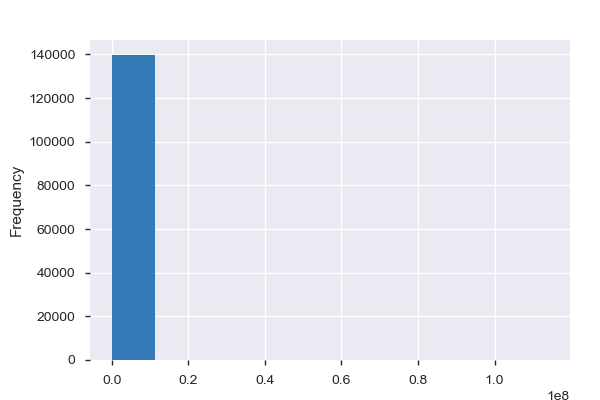

**Common Values**

| Value | Count | Frequency (%) |  |
| --- | --- | --- | --- |
| 60000.0 | 6137 | 4.3% |  |
| 50000.0 | 4645 | 3.3% |  |
| 30000.0 | 4635 | 3.3% |  |
| 40000.0 | 3987 | 2.8% |  |
| 75000.0 | 3571 | 2.5% |  |
| 65000.0 | 3362 | 2.4% |  |
| 70000.0 | 3286 | 2.3% |  |
| 48000.0 | 3271 | 2.3% |  |
| 36000.0 | 3251 | 2.3% |  |
| 80000.0 | 3206 | 2.3% |  |
| Other values (7135) | 100266 | 70.7% |  |

**Extreme Values**

Minimum 5 values

| Value | Count | Frequency (%) |  |
| --- | --- | --- | --- |
| 0.0 | 4 | 0.0% |  |
| 2.0 | 1 | 0.0% |  |
| 3.0 | 1 | 0.0% |  |
| 35.0 | 1 | 0.0% |  |
| 42.0 | 1 | 0.0% |  |

Maximum 5 values

| Value | Count | Frequency (%) |  |
| --- | --- | --- | --- |
| 9900000.0 | 1 | 0.0% |  |
| 15000000.0 | 1 | 0.0% |  |
| 23160000.0 | 1 | 0.0% |  |
| 29556000.0 | 1 | 0.0% |  |
| 114000000.0 | 1 | 0.0% |  |

state  
Categorical

| Distinct count | 53 |
| --- | --- |
| Unique (%) | 0.0% |
| Missing (%) | 0.0% |
| Missing (n) | 10 |

| CA | 11004 |
| --- | --- |
| VA | 8612 |
| FL | 8021 |
| Other values (49) | 114268 |

Toggle details

| Value | Count | Frequency (%) |  |
| --- | --- | --- | --- |
| CA | 11004 | 7.8% |  |
| VA | 8612 | 6.1% |  |
| FL | 8021 | 5.7% |  |
| IL | 7910 | 5.6% |  |
| GA | 7461 | 5.3% |  |
| TX | 6939 | 4.9% |  |
| NY | 5999 | 4.2% |  |
| MO | 5535 | 3.9% |  |
| PA | 5286 | 3.7% |  |
| OH | 4530 | 3.2% |  |
| Other values (42) | 70608 | 49.8% |  |

traffic_source  
Numeric

| Distinct count | 176 |
| --- | --- |
| Unique (%) | 0.1% |
| Missing (%) | 0.0% |
| Missing (n) | 0 |
| Infinite (%) | 0.0% |
| Infinite (n) | 0 |

| Mean | 2313.6 |
| --- | --- |
| Minimum | 753 |
| Maximum | 3558 |
| Zeros (%) | 0.0% |

Toggle details

**Statistics**

Quantile statistics

| Minimum | 753 |
| --- | --- |
| 5-th percentile | 873 |
| Q1 | 1452 |
| Median | 2736 |
| Q3 | 3090 |
| 95-th percentile | 3336 |
| Maximum | 3558 |
| Range | 2805 |
| Interquartile range | 1638 |

Descriptive statistics

| Standard deviation | 879.97 |
| --- | --- |
| Coef of variation | 0.38035 |
| Kurtosis | -1.3084 |
| Mean | 2313.6 |
| MAD | 797.71 |
| Skewness | -0.56598 |
| Sum | 328331088 |
| Variance | 774340 |
| Memory size | 1.1 MiB |

**Histogram**

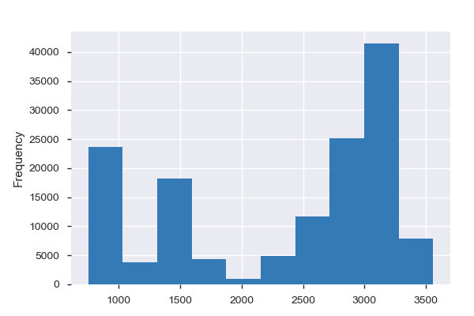

**Common Values**

| Value | Count | Frequency (%) |  |
| --- | --- | --- | --- |
| 3090 | 36529 | 25.7% |  |
| 873 | 18106 | 12.8% |  |
| 2508 | 7841 | 5.5% |  |
| 1494 | 7731 | 5.4% |  |
| 1452 | 7462 | 5.3% |  |
| 2820 | 7268 | 5.1% |  |
| 2880 | 6952 | 4.9% |  |
| 1119 | 3198 | 2.3% |  |
| 2736 | 3042 | 2.1% |  |
| 2904 | 2928 | 2.1% |  |
| Other values (166) | 40858 | 28.8% |  |

**Extreme Values**

Minimum 5 values

| Value | Count | Frequency (%) |  |
| --- | --- | --- | --- |
| 753 | 287 | 0.2% |  |
| 795 | 2 | 0.0% |  |
| 846 | 51 | 0.0% |  |
| 873 | 18106 | 12.8% |  |
| 882 | 1293 | 0.9% |  |

Maximum 5 values

| Value | Count | Frequency (%) |  |
| --- | --- | --- | --- |
| 3429 | 11 | 0.0% |  |
| 3432 | 1 | 0.0% |  |
| 3435 | 2 | 0.0% |  |
| 3546 | 17 | 0.0% |  |
| 3558 | 4 | 0.0% |  |

click_id  
Highly correlated

*This variable is highly correlated with `rate_table_id` and should be ignored for analysis*

| Correlation | 0.99737 |
| --- | --- |

is_funded  
Categorical

| Distinct count | 2 |
| --- | --- |
| Unique (%) | 0.0% |
| Missing (%) | 0.0% |
| Missing (n) | 0 |

| f | 139772 |
| --- | --- |
| t | 2143 |

Toggle details

| Value | Count | Frequency (%) |  |
| --- | --- | --- | --- |
| f | 139772 | 98.5% |  |
| t | 2143 | 1.5% |  |

is_mobile  
Unsupported

*This variable is an unsupported type, check if it needs cleaning or further analysis*

| Unsupported value |
| --- |

Correlations

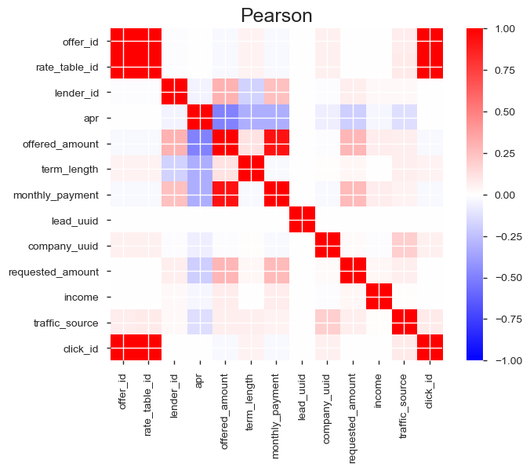

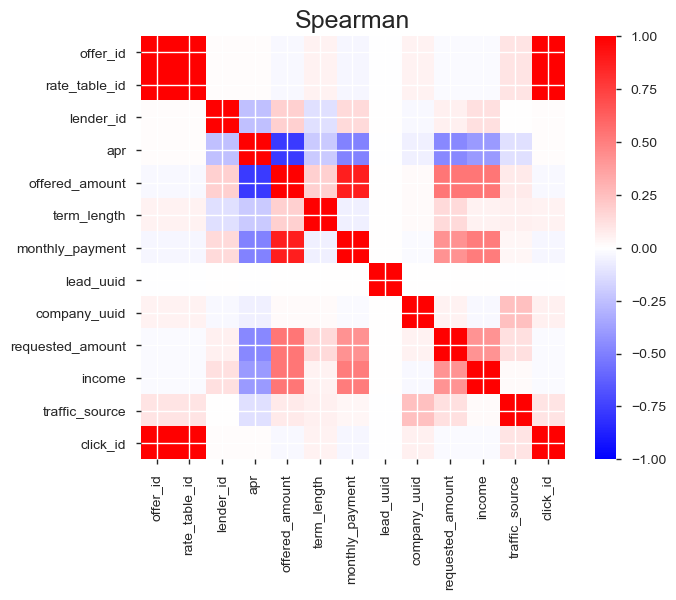

Sample

|  | offer_id | rate_table_id | lead_created_at | lender_id | apr | offered_amount | term_length | term_unit | monthly_payment | lead_uuid | rate_table_created_at | company_uuid | credit_rating | loan_purpose | requested_amount | income | state | traffic_source | click_id | is_funded | is_mobile |
| --- | --- | --- | --- | --- | --- | --- | --- | --- | --- | --- | --- | --- | --- | --- | --- | --- | --- | --- | --- | --- | --- |
| 0 | 1495765590 | 274688181 | 2019-03-05T04:19:43Z | 1 | 27.9500 | 16500 | 36 | month | 649.67 | 395590827986471346 | 2019-03-05T04:19:34Z | 3973050536950353272 | good | debt_consolidation | 15000.0 | 80000.0 | NH | 3090 | 812737593 | f | True |
| 1 | 1510816161 | 278645454 | 2019-03-12T19:47:31Z | 2 | 148.2380 | 1300 | 24 | month | 176.37 | 2887757516335649345 | 2019-03-12T19:47:25Z | 8484512372439812541 | fair | auto | 40000.0 | 62000.0 | VA | 1452 | 812887023 | f | True |
| 2 | 1556028699 | 295675917 | 2019-04-22T09:15:27Z | 3 | 29.5000 | 19200 | 24 | month | 1015.03 | 3424475664079068159 | 2019-04-22T09:15:19Z | 3973050536950353272 | good | debt_consolidation | 25000.0 | 55000.0 | CA | 3090 | 813691164 | f | True |
| 3 | 1531060266 | 285893973 | 2019-03-29T15:41:04Z | 4 | 14.4439 | 40000 | 60 | month | 911.77 | -6902663315616540779 | 2019-03-29T15:40:55Z | 3973050536950353272 | excellent | debt_consolidation | 100000.0 | 120000.0 | NC | 3090 | 813148590 | f | NaN |
| 4 | 1534790916 | 287587872 | 2019-04-02T14:34:19Z | 4 | 18.3089 | 9600 | 36 | month | 327.64 | 6583851389625060753 | 2019-04-02T14:34:13Z | 3973050536950353272 | fair | debt_consolidation | 6000.0 | 52000.0 | PA | 3090 | 813207081 | f | True |

```python
pp.ProfileReport(df)
```

From the above profile report, there are total of 141915 observations and 21 variables. Not all the variables are needed for the model.

1. The dataset has 1 duplicate row. The duplicated observation should be removed.
2. offer_id, rate_table_id, click_id, lead_uuid, are unique ids, which doesn't provide too much information. They should be dropped for the model.
3. lead_created_at, rate_table_created_at are also unique timestamps. They can be dropped.
4. monthly_payment is highly correlated with offered_amount and should be ignored for analysis.

The rest of variables might be useful features for the model and they should be kept for further analysis:

- **apr**, **offered_amount**, **requested_amount**, **income** are numerical varibles. Their distributions are highly right skewed. **requested_amount** and **income** have missing values.
- **traffic_source** is listed as numeric variable here. However, based on the description of this variable: ID of the source through which lead was acquired, it should be a categorical variable.
- **term_length** and **term_unit** can be combined into one varible using the same loan term unit.
- **credit_rating**, **loan_purpose**, **state** are categorical variables and have missing values. Some categories for these variables only have a few observations, so those categories can be combined into one category and name'other'.
- **lender_id** has 20 distinct values. They should be included as a categorical variable.
- **is_mobile** has a large proportion of missing values, it's not a reliable feature for building the model. So it should be dropped for the modeling.
- **is_funded** is the dependent variable that we want to predict. However, the class is highly imbalanced. Oversampling or downsampling is necessary before building the model.

## Data cleaning

#### Remove duplicates

```python
#remove duplicate rows
df.drop_duplicates(keep=False, inplace=True)
df = df.reset_index(drop = True)
```

#### Term_length and term_unit

```python
#combine term_length and term_unit into one column.
#here, I converted all the values into days.
for i in range(len(df)):
    if df['term_unit'][i] == 'month':
        df['term_length'][i] = df['term_length'][i]*30
    elif df['term_unit'][i] == 'year':
        df['term_length'][i] = df['term_length'][i]*365
```

#### Credit rating

```python
#drop missing credit_rating with 'unknown' as new category
df.drop( df[ df['credit_rating'] == 'unknown' ].index , inplace=True)
df = df.reset_index(drop = True)
```

#### Loan purpose

```python
#check the number of observations for each loan purpose category
df['loan_purpose'].value_counts()
```

```
debt_consolidation    103910
other                  12807
home_improvement        7183
auto                    3904
large_purchases         2600
medical_dental          2430
credit_card_refi        1936
business                1464
wedding                 1342
vacation                 974
student_loan             950
moving_relocation        742
household_expenses       740
taxes                    469
unknown                  111
baby                     105
life_event               101
boat                      57
green                     35
cosmetic                  10
Name: loan_purpose, dtype: int64
```

```python
#fill in missing loan purpose with 'unkown'
df['loan_purpose'] = df['loan_purpose'].fillna('unknown')

#combine some categories with number of observations less than 100 into one category 'other'
Other = ['baby','life_event','boat','green','cosmetic']
df['loan_purpose'].loc[df['loan_purpose'].isin(Other)] = 'other'

df['loan_purpose'].value_counts()
```

```
debt_consolidation    103910
other                  13115
home_improvement        7183
auto                    3904
large_purchases         2600
medical_dental          2430
credit_card_refi        1936
business                1464
wedding                 1342
vacation                 974
student_loan             950
moving_relocation        742
household_expenses       740
taxes                    469
unknown                  150
Name: loan_purpose, dtype: int64
```

#### State

```python
#drop rows with missing values and combine rows with too few observations into one category 'other'
df['state'] = df['state'].dropna()
df['state'].value_counts()
```

```
CA    11004
VA     8612
FL     8018
IL     7910
GA     7461
TX     6939
NY     5999
MO     5535
PA     5286
OH     4530
WI     4519
MN     4464
WA     4460
OR     3903
AL     3730
SC     3726
MI     3199
NJ     3176
AZ     2628
NC     2446
UT     2430
MD     2398
IN     2348
TN     2218
CO     2119
NM     1701
MA     1663
NE     1468
LA     1432
ID     1378
DE     1246
KY     1215
OK     1132
KS     1016
CT     1015
NV      975
HI      913
ND      863
MS      856
IA      830
AR      796
NH      763
MT      666
WV      630
ME      597
SD      555
WY      486
RI      345
AK      171
VT       93
DC       18
PR       18
Name: state, dtype: int64
```

```python
Other = ['WY','RI','AK','VT','PR','DC']
df['state'].loc[df['state'].isin(Other)] = 'other'
```

#### Requested amount and income

```python
#due to high skewness, fill in the missing values with median for numerical variables requested_amount and income.
df['requested_amount'] = df['requested_amount'].fillna(df['requested_amount'].median())
df['income'] = df['income'].fillna(df['income'].median())
```

#### Traffic source

```python
#convert other numerical varible into categorical variable for traffic_source
df['traffic_source'] = df['traffic_source'].astype(str)

df['traffic_source'].value_counts()
```

```
3090    36529
873     18106
2508     7841
1494     7731
1452     7462
        ...
3432        1
1179        1
2793        1
2622        1
2061        1
Name: traffic_source, Length: 176, dtype: int64
```

```python
#get the traffic_source id with observations less than 100
cat_list = df['traffic_source'].value_counts().to_frame()

#combine those categories with too few observations into one category 'other'
to_combine = []
for i in range(len(cat_list)):
    if cat_list['traffic_source'][i] < 100:
        to_combine.append(cat_list.index[i])

df['traffic_source'].loc[df['traffic_source'].isin(to_combine)] = 'other'
df['traffic_source'].value_counts()
```

```
3090    36529
873     18106
2508     7841
1494     7731
1452     7462
        ...
2460      121
2919      121
1647      116
2277      116
1854      108
Name: traffic_source, Length: 63, dtype: int64
```

#### Lender id

```python
df['lender_id'].value_counts()
```

```
5     28228
4     27223
2     25031
10    14461
1     10785
8      9465
9      4263
3      3239
6      3046
11     2988
7      2894
17     2425
14     2069
15     1796
12     1645
13     1512
18      463
19      225
16       80
20       71
Name: lender_id, dtype: int64
```

#### Company uuid

```python
#convert other numerical varible into categorical variable
df['company_uuid'] = df['company_uuid'].astype(str)
df['company_uuid'].value_counts()
```

```
3973050536950353272     36529
-4633008154237388280    18106
-287173439723278177      7841
3242147885092572777      7731
8484512372439812541      7462
                        ...
4278730302435213445         1
2312957137877286760         1
4462988036615264228         1
-963510488335810539         1
-6529694314856069557        1
Name: company_uuid, Length: 176, dtype: int64
```

```python
#get the company_uuid with observations less than 100
cat_list = df['company_uuid'].value_counts().to_frame()

#combine those categories with too few observations into one category 'other'
to_combine = []
for i in range(len(cat_list)):
    if cat_list['company_uuid'][i] < 100:
        to_combine.append(cat_list.index[i])

df['company_uuid'].loc[df['company_uuid'].isin(to_combine)] = 'other'
df['company_uuid'].value_counts()
```

```
3973050536950353272     36529
-4633008154237388280    18106
-287173439723278177      7841
3242147885092572777      7731
8484512372439812541      7462
                        ...
1120801594836716302       121
-8567265432502907529      121
-8972015782597401600      116
-4883852027595839442      116
2007440565106444675       108
Name: company_uuid, Length: 63, dtype: int64
```

```python
#drop all the unnecessary features
feature_to_keep = ['apr','offered_amount','term_length','lender_id','credit_rating','loan_purpose','requested_amount',
                   'income','state','traffic_source','company_uuid','is_funded']
df = df[feature_to_keep]
df.head(2)
```

|  | apr | offered_amount | term_length | lender_id | credit_rating | loan_purpose | requested_amount | income | state | traffic_source | company_uuid | is_funded |
| --- | --- | --- | --- | --- | --- | --- | --- | --- | --- | --- | --- | --- |
| 0 | 27.950 | 16500 | 1080 | 1 | good | debt_consolidation | 15000.0 | 80000.0 | NH | 3090 | 3973050536950353272 | f |
| 1 | 148.238 | 1300 | 720 | 2 | fair | auto | 40000.0 | 62000.0 | VA | 1452 | 8484512372439812541 | f |

## Exploratory data analysis

```
Dataset has 109467 rows and 12 columns.
```

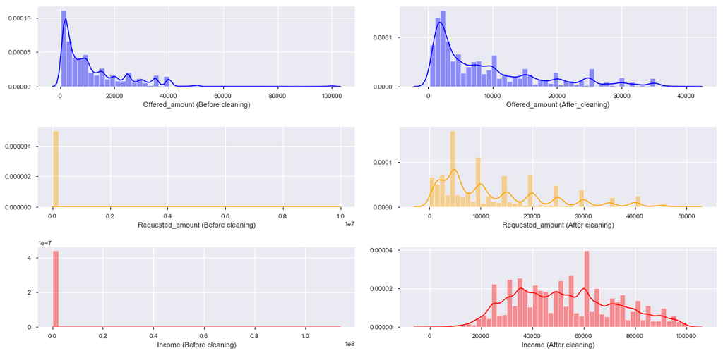

```python
# check the distribution of income, requested_amount,term_length, offered_amount
%matplotlib inline
fig,axs = plt.subplots(ncols = 2, nrows = 3, figsize = (16,8))
plt.subplots_adjust(left=0, bottom=0, right=1, top=0.9,hspace=0.5,wspace=0.3)
sns.set(style = "white",font_scale=1.5)

sns.distplot(pd.Series(df['offered_amount'],name = "Offered_amount (Before cleaning)"),color = 'blue', ax = axs[0,0])
sns.distplot(pd.Series(df['requested_amount'], name = "Requested_amount (Before cleaning)"), color = "orange",ax = axs[1,0])
sns.distplot(pd.Series(df['income'],name = "Income (Before cleaning)"),color = 'red', ax = axs[2,0])

new_df = df[df['offered_amount']<40000]
new_df = new_df[new_df['requested_amount']<50000]
new_df = new_df[new_df['income']<100000]

sns.distplot(pd.Series(new_df['offered_amount'],name = "Offered_amount (After_cleaning)"),color = 'blue', ax = axs[0,1])
sns.distplot(pd.Series(new_df['requested_amount'],name = "Requested_amount (After cleaning)"), color = "orange",ax = axs[1,1])
sns.distplot(pd.Series(new_df['income'],name = "Income (After cleaning)"),color = 'red', ax = axs[2,1])

save_fig("Distribution_of_variables1")

print ("Dataset has {} rows and {} columns.".format(*new_df.shape))
```

The distributions for these three numerical variables are highly skewed. I removed those extremely large values because it's unlikely that there is enough data to make tailored predictions for those extreme data points.

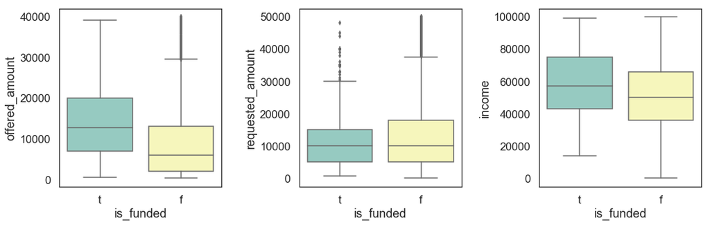

```python
fig,axs = plt.subplots(ncols = 3, nrows = 1, figsize = (15,5))
plt.subplots_adjust(left=0, bottom=0, right=1, top=0.9,hspace=0.5,wspace=0.3)
sns.set(style = "white",font_scale=1.5)

sns.boxplot(data = new_df, x = 'is_funded', y = 'offered_amount', palette="Set3",order = ['t','f'],ax = axs[0])
sns.boxplot(data = new_df, x = 'is_funded', y = 'requested_amount', palette="Set3",order = ['t','f'],ax = axs[1])
sns.boxplot(data = new_df, x = 'is_funded', y = 'income', palette="Set3", order = ['t','f'],ax = axs[2])

save_fig("Distribution_of_variables2")
```

For those funded loan offers, the average offered amount and average income are higher than those non-funded loan offers whereas the distribution for requested_amount for non-funded loan offers is broader than funded loan offers.

```python
#get the funded loan offer ratio for different credit ratings
funded = new_df[new_df['is_funded'] == 't']
notfunded = new_df[new_df['is_funded'] == 'f']
funded_credit = funded['credit_rating'].value_counts().reset_index()
funded_credit.columns = ['credit_rating','count']

nonfunded_credit = notfunded['credit_rating'].value_counts().reset_index()
nonfunded_credit.columns = ['credit_rating','count']
```

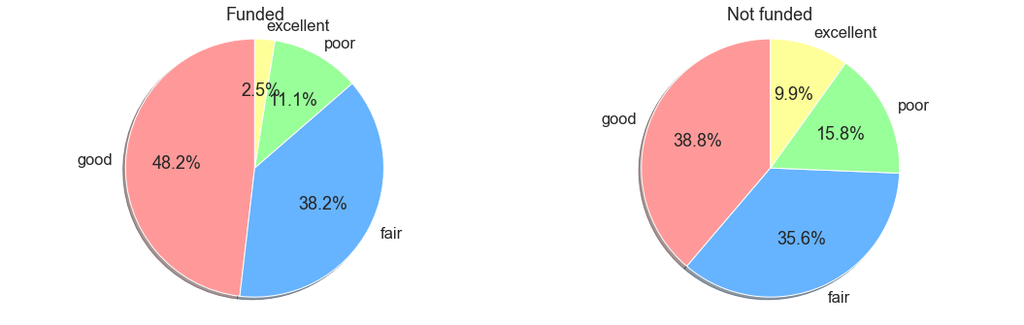

```python
# Pie chart
labels = ['good', 'fair', 'poor','excellent']
sizes = funded_credit['count']
explode = [0,0,0,0]
colors = ['#ff9999','#66b3ff','#99ff99','#FEFF99']

fig, (ax1, ax2) = plt.subplots(1, 2,figsize = (15,5))
ax1.pie(sizes, explode=explode, labels=labels, autopct='%1.1f%%',
        shadow=True, colors = colors,startangle=90)

ax1.axis('equal')
ax1.title.set_text('Funded')


sizes = nonfunded_credit['count']
ax2.pie(sizes, explode=explode, labels=labels, autopct='%1.1f%%',
        shadow=True, colors = colors,startangle=90)

ax2.axis('equal')
ax2.title.set_text('Not funded')

plt.tight_layout()
save_fig("Funded_ratio")
```

```python
#get the funded ratio for different loan purposes
df_purpose = new_df['loan_purpose'].value_counts().reset_index()
df_purpose.columns = ['loan_purpose','count']

funded_purpose = funded['loan_purpose'].value_counts().reset_index()
funded_purpose.columns = ['loan_purpose','count']

df_purpose_rate = pd.merge(df_purpose,funded_purpose,on = 'loan_purpose')
df_purpose_rate.columns = ['loan_purpose','Total_number','Funded_number']

df_purpose_rate['Funded_rate'] = df_purpose_rate['Funded_number']/df_purpose_rate['Total_number']
#df_purpose_rate = df_purpose_rate.sort_values(by = 'Funded_rate')
```

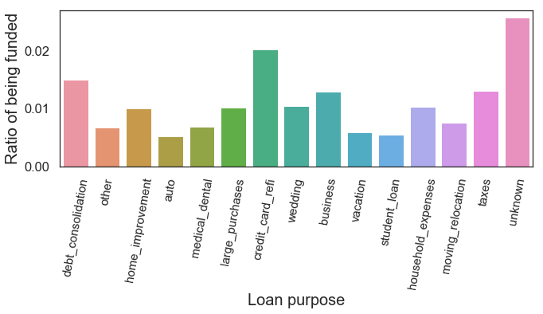

```python
#plot
fig,axs = plt.subplots(nrows = 1, figsize = (10,6))
sns.set(font_scale = 2)
sns.set_style('white')
p1 = sns.barplot(x = df_purpose_rate['loan_purpose'], y = df_purpose_rate['Funded_rate'],data = df_purpose_rate)
p1.set_xticklabels(p1.get_xticklabels(),rotation=80,fontsize=15)
p1.set_xlabel('Loan purpose',fontsize=20)
p1.set_ylabel('Ratio of being funded',fontsize = 20)

plt.tight_layout()
save_fig("Funded_ratio_loan_purpose")
```

Loans used for unknown purpose, credit_card_refi and debt_consolidation have the top 3 highest conversion rate whereas loan used for auto, student_loan and vacation have the lowest conversion rate.

```python
#get the funded ratio for different states
df_state = new_df['state'].value_counts().reset_index()
df_state.columns = ['state','count']

funded_state = funded['state'].value_counts().reset_index()
funded_state.columns = ['state','count']

df_state_rate = pd.merge(df_state,funded_state,on = 'state')
df_state_rate.columns = ['state','Total_number','Funded_number']

df_state_rate['Funded_rate'] = df_state_rate['Funded_number']/df_state_rate['Total_number']
```

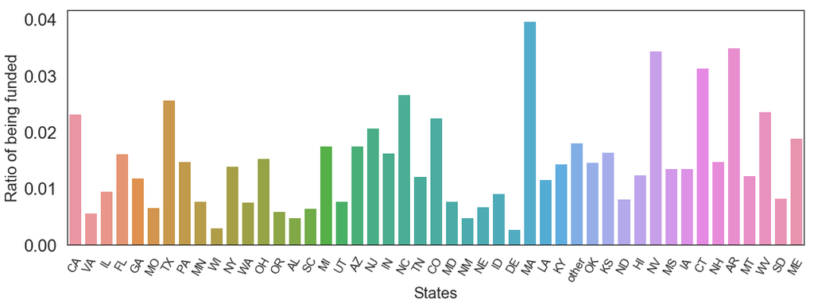

```python
#plot
fig,axs = plt.subplots(nrows = 1, figsize = (15,6))
sns.set(font_scale = 2)
sns.set_style('white')
p1 = sns.barplot(x = df_state_rate['state'], y = df_state_rate['Funded_rate'],data = df_state_rate)
p1.set_xticklabels(p1.get_xticklabels(),rotation=60,fontsize=15)
p1.set_xlabel('States',fontsize=20)
p1.set_ylabel('Ratio of being funded',fontsize = 20)

plt.tight_layout()
save_fig("Funded_ratio_state")
```

The conversion rate among different states are quite different. MA, NV and AR have the highest conversion rate whereas DE,WI and NM have lowest conversion rate.

```python
#lender_id
df_lender = new_df['lender_id'].value_counts().reset_index()
df_lender.columns = ['lender_id','count']

funded_lender = funded['lender_id'].value_counts().reset_index()
funded_lender.columns = ['lender_id','count']

df_lender_rate = pd.merge(df_lender,funded_lender,on = 'lender_id')
df_lender_rate.columns = ['lender_id','Total_number','Funded_number']

df_lender_rate['Funded_rate'] = df_lender_rate['Funded_number']/df_lender_rate['Total_number']
```

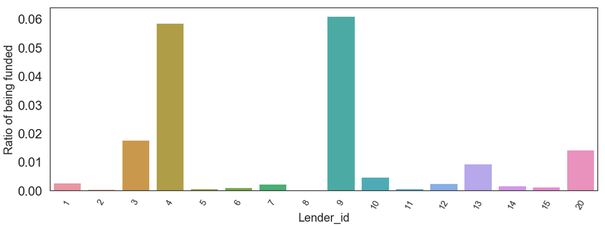

```python
fig,axs = plt.subplots(nrows = 1, figsize = (15,6))
sns.set(font_scale = 2)
sns.set_style('white')
p1 = sns.barplot(x = df_lender_rate['lender_id'], y = df_lender_rate['Funded_rate'],data = df_lender_rate)
p1.set_xticklabels(p1.get_xticklabels(),rotation=60,fontsize=15)
p1.set_xlabel('Lender_id',fontsize=20)
p1.set_ylabel('Ratio of being funded',fontsize = 20)

plt.tight_layout()
save_fig("Funded_ratio_lenderId")
```

The conversion rate among different lenders are also quite different. Conversion rate for lender 4 and 9 are significantly higher than other lenders.

```python
#company_uuid
df_company = new_df['company_uuid'].value_counts().reset_index()
df_company.columns = ['company_uuid','count']

funded_company = funded['company_uuid'].value_counts().reset_index()
funded_company.columns = ['company_uuid','count']

df_company_rate = pd.merge(df_company,funded_company,on = 'company_uuid')
df_company_rate.columns = ['company_uuid','Total_number','Funded_number']

df_company_rate['Funded_rate'] = df_company_rate['Funded_number']/df_company_rate['Total_number']
```

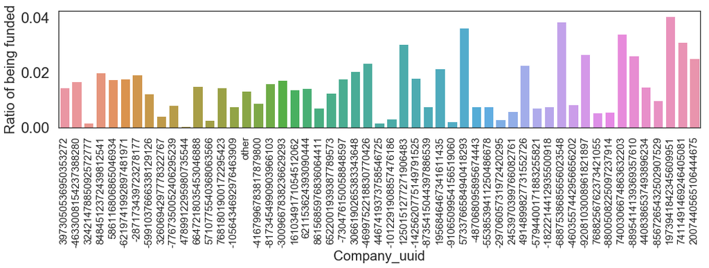

```python
fig,axs = plt.subplots(nrows = 1, figsize = (15,6))
sns.set(font_scale = 2)
sns.set_style('white')
p1 = sns.barplot(x = df_company_rate['company_uuid'], y = df_company_rate['Funded_rate'],data = df_company_rate)
p1.set_xticklabels(p1.get_xticklabels(),rotation=90,fontsize=15)
p1.set_xlabel('Company_uuid',fontsize=20)
p1.set_ylabel('Ratio of being funded',fontsize = 20)

plt.tight_layout()
save_fig("Funded_ratio_companyuuid")
```

```python
#save the cleaned dataframe for later modeling
final_df = new_df.copy()
```

# III. Machine learning model

In this part, I will try five machine learning models: logistic regression, K nearest neighbors, SVC, decision tree and random forest. Before training the model,

1. Check **class imbalance** and **correlation coefficients**
2. If the class is highly imbalanced, oversampling techniques such as **SMOTE** will be used to balance the two classes.
3. Data preprocessing: label encoding the dependent variable 'is_funded' and one-hot encoding for all the categorical variables.
4. Try the above listed five machine learning models.
5. Considering the possible imbalanced class, **confusion matrix** and **roc-auc score** need to be used for evaluation metrics.

### Data preprocessing

```
Class f (not_funded): 108028
Class t (funded): 1439
Percentage: 0.99 vs. 0.01
```

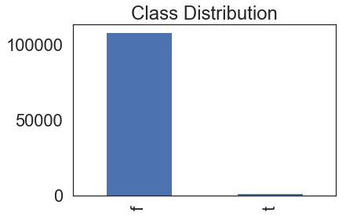

```python
#check class balance
funded_count = final_df.is_funded.value_counts()
print('Class f (not_funded):', funded_count[0])
print('Class t (funded):', funded_count[1])
print('Percentage:', round(funded_count[0] / len(final_df), 2),'vs.', round(funded_count[1] / len(final_df), 2))

funded_count.plot(kind='bar', title='Class Distribution')
```

The two classes are highly imbalanced. There are much more data points for non_funded loan offers than funded loan offers.

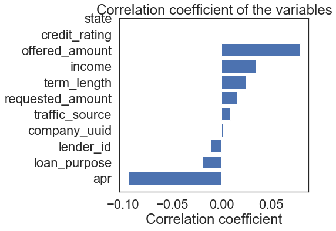

```python
#check correlation coefficient for variables
from scipy.stats import spearmanr,pearsonr

labels = []
values = []
for col in final_df.columns:
    if col not in ['is_funded']:
        labels.append(col)
        values.append(spearmanr(final_df[col].values, final_df['is_funded'].values)[0])
corr_df = pd.DataFrame({'col_labels':labels, 'corr_values':values})
corr_df = corr_df.sort_values(by='corr_values')

#corr_df = corr_df[(corr_df['corr_values']>0.05) | (corr_df['corr_values']<-0.05)]
ind = np.arange(corr_df.shape[0])
width = 0.9
fig, ax = plt.subplots(figsize=(8,6))
rects = ax.barh(ind, np.array(corr_df.corr_values.values), color='b')
ax.set_yticks(ind)
ax.set_yticklabels(corr_df.col_labels.values, rotation='horizontal')
ax.set_xlabel("Correlation coefficient")
ax.set_title("Correlation coefficient of the variables")
save_fig("Funded_ratio_companyuuid")
```

```python
# Label encoding
le = LabelEncoder()
final_df['is_funded'] = le.fit_transform(final_df['is_funded'])

# One-hot encoding
final_df = pd.get_dummies(final_df,columns = ['credit_rating','loan_purpose','state','traffic_source','company_uuid','lender_id'])
```

```python
#visualize
non_funded = final_df[final_df['is_funded'] == 0].sample(8000)
funded = final_df[final_df['is_funded'] == 1]

sample_df = non_funded.append(funded).sample(frac=1).reset_index(drop=True)
X = sample_df.drop(['is_funded'], axis = 1).values
Y = sample_df["is_funded"].values
```

```python
def tsne_plot(x1, y1, name="graph.png"):
    tsne = TSNE(n_components=2, perplexity=100, random_state=0)
    X_t = tsne.fit_transform(x1)

    plt.figure(figsize=(12, 8))
    plt.scatter(X_t[np.where(y1 == 0), 0], X_t[np.where(y1 == 0), 1], marker='o', color='g', linewidth='1', alpha=0.8, label='Non funded')
    plt.scatter(X_t[np.where(y1 == 1), 0], X_t[np.where(y1 == 1), 1], marker='o', color='r', linewidth='1', alpha=0.8, label='Funded')

    plt.legend(loc='best')
    plt.title("t-sne")
    plt.savefig(name)
    plt.show()
```

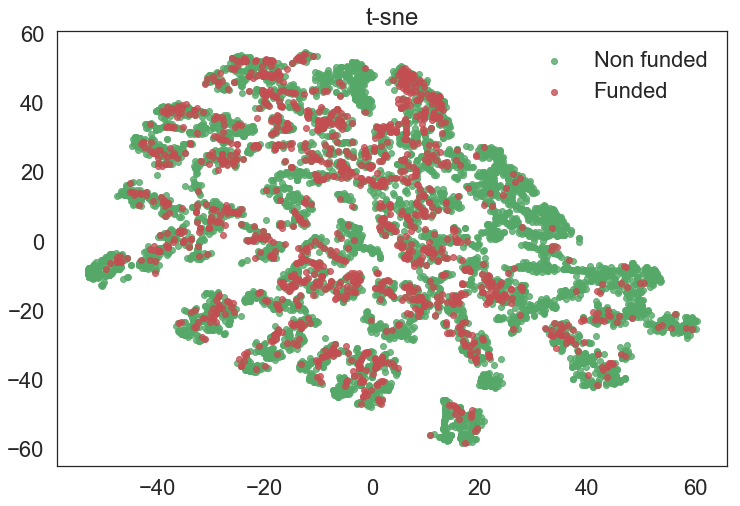

```python
# Plot t-sne
tsne_plot(X, Y, "original.png")
```

```python
#split the dataset
X = final_df.drop(['is_funded'],axis = 1)
y = final_df['is_funded']

seed = 157
X_train,X_test,y_train,y_test = train_test_split(X,y,random_state=seed)
```

```python
#SMOTE
sm = SMOTE(random_state = 2)
X_train, y_train = sm.fit_sample(X_train, y_train.ravel())

print('After OverSampling, the shape of train_X: {}'.format(X_train.shape))
print('After OverSampling, the shape of train_y: {} \n'.format(y_train.shape))

#0 represents funded, and 1 represents not funded
print("After OverSampling, counts of label '0': {}".format(sum(y_train==0)))
print("After OverSampling, counts of label '1': {}".format(sum(y_train==1)))
```

```
After OverSampling, the shape of train_X: (162064, 217)
After OverSampling, the shape of train_y: (162064,)

After OverSampling, counts of label '0': 81032
After OverSampling, counts of label '1': 81032
```

### Machine learning models

```python
import itertools

# Create a confusion matrix
def plot_confusion_matrix(cm, classes,
                          normalize=False,
                          title='Confusion matrix',
                          cmap=plt.cm.Blues):
    """
    This function prints and plots the confusion matrix.
    Normalization can be applied by setting `normalize=True`.
    """
    if normalize:
        cm = cm.astype('float') / cm.sum(axis=1)[:, np.newaxis]
        print("Normalized confusion matrix")
    else:
        print('Confusion matrix, without normalization')

    print(cm)

    plt.imshow(cm, interpolation='nearest', cmap=cmap)
    plt.title(title, fontsize=14)
    plt.colorbar()
    tick_marks = np.arange(len(classes))
    plt.xticks(tick_marks, classes, rotation=45)
    plt.yticks(tick_marks, classes)

    fmt = '.2f' if normalize else 'd'
    thresh = cm.max() / 2.
    for i, j in itertools.product(range(cm.shape[0]), range(cm.shape[1])):
        plt.text(j, i, format(cm[i, j], fmt),
                 horizontalalignment="center",
                 color="white" if cm[i, j] > thresh else "black")

    plt.tight_layout()
    plt.ylabel('True label')
    plt.xlabel('Predicted label')
```

```python
# Let's try different classifiers
classifiers = {
    "LogisiticRegression": LogisticRegression(solver='liblinear'),
    "KNearest": KNeighborsClassifier(),
    "Support Vector Classifier": SVC(gamma='scale',cache_size=200),
    "DecisionTreeClassifier": DecisionTreeClassifier(),
    "RandomForestClassifier": RandomForestClassifier(n_estimators=100)
}
```

```
Classifiers:  LogisticRegression Has a training score of 94.0 % accuracy score
--------------------------------------------------------------------------------
Classification Report:
              precision    recall  f1-score   support

           0       0.99      0.97      0.98     26996
           1       0.07      0.19      0.11       371

    accuracy                           0.96     27367
   macro avg       0.53      0.58      0.54     27367
weighted avg       0.98      0.96      0.97     27367


Accuracy Score:  0.9561150290495852

Roc-auc score:  0.5789996741056578

Normalized confusion matrix
[[0.96662469 0.03337531]
 [0.80862534 0.19137466]]
```

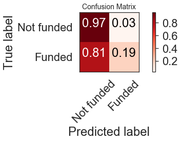

```
Classifiers:  KNeighborsClassifier Has a training score of 93.0 % accuracy score
--------------------------------------------------------------------------------
Classification Report:
              precision    recall  f1-score   support

           0       0.99      0.90      0.94     26996
           1       0.03      0.22      0.05       371

    accuracy                           0.89     27367
   macro avg       0.51      0.56      0.49     27367
weighted avg       0.98      0.89      0.93     27367


Accuracy Score:  0.8869075894325282

Roc-auc score:  0.5572122794272407

Normalized confusion matrix
[[0.89609572 0.10390428]
 [0.78167116 0.21832884]]
```

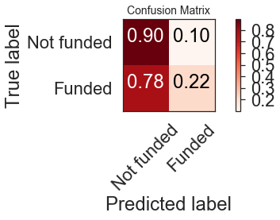

```
Classifiers:  SVC Has a training score of 69.0 % accuracy score
--------------------------------------------------------------------------------
Classification Report:
              precision    recall  f1-score   support

           0       0.99      0.58      0.74     26996
           1       0.03      0.78      0.05       371

    accuracy                           0.59     27367
   macro avg       0.51      0.68      0.39     27367
weighted avg       0.98      0.59      0.73     27367


Accuracy Score:  0.5863265977271896

Roc-auc score:  0.6839857776673715

Normalized confusion matrix
[[0.58360498 0.41639502]
 [0.21563342 0.78436658]]
```

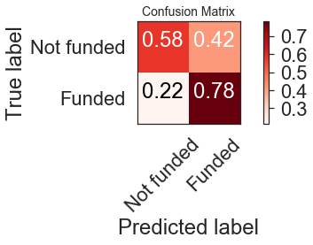

```
Classifiers:  DecisionTreeClassifier Has a training score of 98.0 % accuracy score
--------------------------------------------------------------------------------
Classification Report:
              precision    recall  f1-score   support

           0       0.99      0.98      0.99     26996
           1       0.06      0.07      0.06       371

    accuracy                           0.97     27367
   macro avg       0.52      0.53      0.52     27367
weighted avg       0.97      0.97      0.97     27367


Accuracy Score:  0.9719004640625571

Roc-auc score:  0.5271874160053263

Normalized confusion matrix
[[0.98429397 0.01570603]
 [0.92991914 0.07008086]]
```

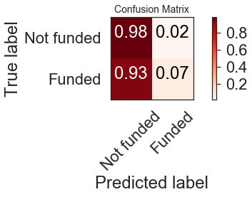

```
Classifiers:  RandomForestClassifier Has a training score of 99.0 % accuracy score
--------------------------------------------------------------------------------
Classification Report:
              precision    recall  f1-score   support

           0       0.99      1.00      0.99     26996
           1       0.13      0.01      0.02       371

    accuracy                           0.99     27367
   macro avg       0.56      0.50      0.50     27367
weighted avg       0.97      0.99      0.98     27367


Accuracy Score:  0.9858223407753864

Roc-auc score:  0.5036727014364513

Normalized confusion matrix
[[9.99259150e-01 7.40850496e-04]
 [9.91913747e-01 8.08625337e-03]]
```

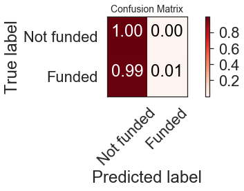

```python
from sklearn.model_selection import cross_val_score
from sklearn.metrics import classification_report, f1_score, accuracy_score, confusion_matrix,roc_auc_score

for key, classifier in classifiers.items():
    classifier.fit(X_train, y_train)
    y_pred = classifier.predict(X_test)
    training_score = cross_val_score(classifier, X_train, y_train, cv=5)
    #training_score = f1_score(classifier, X_train, y_train, average='weighted')
    print("Classifiers: ", classifier.__class__.__name__, "Has a training score of", round(training_score.mean(), 2) * 100, "% accuracy score")
    print("-"*80)
    print ("Classification Report: ")
    print (classification_report(y_test, y_pred))
    print ("")
    print ("Accuracy Score: ", accuracy_score(y_test, y_pred))
    print ("")
    print ("Roc-auc score: ", roc_auc_score(y_test, y_pred))
    print ("")

    # Plot confusion matrix
    labels = ['Not funded', 'Funded']
    fig = plt.figure(figsize=(8,4))
    plot_confusion_matrix(confusion_matrix(y_test, y_pred), labels, title="Confusion Matrix", cmap=plt.cm.Reds,normalize=True)
    plt.show()
```

All the models are good at correctly predicting nonfunded loan offers except SVC. However, the false negative rate, meaning that the model predicts the loan offer won't be funded while the loan offer is accepted and funded in actual data, is quite high for these four models. Thus, the overall AUC scores for these models are quite low.

# III. Model improvement with autoencoder

In this part, **autoencoder** will be used to decrease false negative rate and further improve model's performance.

```python
#reload the clean dataset and preprocessing the dataset
final_df = new_df.copy()

# Label encoding
le = LabelEncoder()
final_df['is_funded'] = le.fit_transform(final_df['is_funded'])

# One-hot encoding
final_df = pd.get_dummies(final_df,columns = ['credit_rating','loan_purpose','state','traffic_source','company_uuid','lender_id'])
```

```python
# Input layer
input_layer = Input(shape=(X.shape[1],))

# Encoding part
encoded = Dense(100, activation='tanh', activity_regularizer=regularizers.l1(10e-5))(input_layer)
encoded = Dense(50, activation='relu')(encoded)

# Decoding part
decoded = Dense(50, activation='tanh')(encoded)
decoded = Dense(100, activation='tanh')(decoded)

# Output layer
output_layer = Dense(X.shape[1], activation='relu')(decoded)
```

```python
autoencoder = Model(input_layer, output_layer)
#autoencoder.compile(optimizer="adadelta", loss="mse")
autoencoder.compile(optimizer="adadelta", loss="binary_crossentropy")
```

```python
final_df.sample(frac=1, replace=True)
x = final_df.drop(["is_funded"], axis=1)
y = final_df["is_funded"].values

#scale dataset
x_nofund, x_fund = x[y == 0], x[y == 1]
x_scale = preprocessing.MinMaxScaler().fit_transform(x.values)
x_nofund, x_fund = x_scale[y == 0], x_scale[y == 1]
```

```python
autoencoder.fit(x_nofund[0:8000], x_nofund[0:8000],
                batch_size = 256, epochs = 20,
                shuffle = True, validation_split = 0.20)
```

```
Train on 6400 samples, validate on 1600 samples
```

```
<keras.callbacks.callbacks.History at 0x1a45756810>
```

```python
hidden_representation = Sequential()
hidden_representation.add(autoencoder.layers[0])
hidden_representation.add(autoencoder.layers[1])
hidden_representation.add(autoencoder.layers[2])
```

```python
notfunded_hid_rep = hidden_representation.predict(x_nofund[:8000])
funded_hid_rep = hidden_representation.predict(x_fund)
```

```python
#append the representations from autoencoder to the dataframe
rep_x = np.append(notfunded_hid_rep, funded_hid_rep, axis = 0)
y_n = np.zeros(notfunded_hid_rep.shape[0])
y_f = np.ones(funded_hid_rep.shape[0])
rep_y = np.append(y_n, y_f)
```

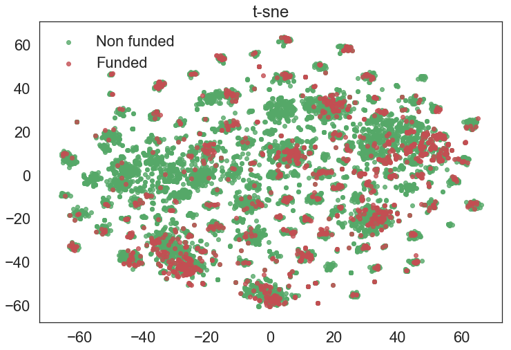

```python
tsne_plot(rep_x, rep_y, "latent_representation.png")
```

```python
from IPython.display import display, Image, HTML
display(HTML("""<table align="center">
<tr ><td><b>Actual Representation (Before) </b></td><td><b>Latent Representation (Actual)</b></td></tr>
<tr><td><img src='original.png'></td><td>
<img src='latent_representation.png'></td></tr></table>"""))
```

[output not shown]

```python
#split the dataset and balance the dataset
X_train, X_test, y_train, y_test = train_test_split(rep_x, rep_y, test_size=0.2, random_state=42)

sm = SMOTE(random_state = 2)
X_train, y_train = sm.fit_sample(X_train, y_train.ravel())
```

```
Classifiers:  LogisticRegression Has a training score of 73.0 % accuracy score
--------------------------------------------------------------------------------
Classification Report:
              precision    recall  f1-score   support

         0.0       0.93      0.67      0.78      1581
         1.0       0.30      0.73      0.43       307

    accuracy                           0.68      1888
   macro avg       0.61      0.70      0.60      1888
weighted avg       0.83      0.68      0.72      1888


Accuracy Score:  0.6811440677966102

Roc-auc score:  0.6993718155540034

Normalized confusion matrix
[[0.67235927 0.32764073]
 [0.27361564 0.72638436]]
```

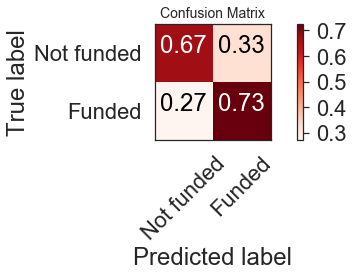

```
Classifiers:  KNeighborsClassifier Has a training score of 84.0 % accuracy score
--------------------------------------------------------------------------------
Classification Report:
              precision    recall  f1-score   support

         0.0       0.93      0.73      0.81      1581
         1.0       0.33      0.70      0.45       307

    accuracy                           0.72      1888
   macro avg       0.63      0.71      0.63      1888
weighted avg       0.83      0.72      0.75      1888


Accuracy Score:  0.7208686440677966

Roc-auc score:  0.7112792999936131

Normalized confusion matrix
[[0.7254902 0.2745098]
 [0.3029316 0.6970684]]
```

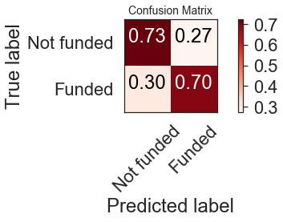

```
Classifiers:  SVC Has a training score of 87.0 % accuracy score
--------------------------------------------------------------------------------
Classification Report:
              precision    recall  f1-score   support

         0.0       0.95      0.82      0.88      1581
         1.0       0.46      0.80      0.58       307

    accuracy                           0.81      1888
   macro avg       0.71      0.81      0.73      1888
weighted avg       0.87      0.81      0.83      1888


Accuracy Score:  0.8130296610169492

Roc-auc score:  0.8083048497322644

Normalized confusion matrix
[[0.81530677 0.18469323]
 [0.19869707 0.80130293]]
```

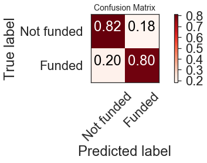

```
Classifiers:  DecisionTreeClassifier Has a training score of 84.0 % accuracy score
--------------------------------------------------------------------------------
Classification Report:
              precision    recall  f1-score   support

         0.0       0.89      0.81      0.85      1581
         1.0       0.32      0.46      0.38       307

    accuracy                           0.75      1888
   macro avg       0.60      0.64      0.61      1888
weighted avg       0.79      0.75      0.77      1888


Accuracy Score:  0.7542372881355932

Roc-auc score:  0.6367099534991049

Normalized confusion matrix
[[0.81087919 0.18912081]
 [0.53745928 0.46254072]]
```

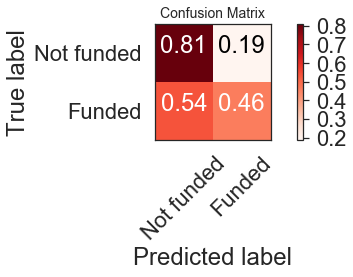

```
Classifiers:  RandomForestClassifier Has a training score of 92.0 % accuracy score
--------------------------------------------------------------------------------
Classification Report:
              precision    recall  f1-score   support

         0.0       0.89      0.91      0.90      1581
         1.0       0.49      0.44      0.46       307

    accuracy                           0.83      1888
   macro avg       0.69      0.68      0.68      1888
weighted avg       0.83      0.83      0.83      1888


Accuracy Score:  0.833156779661017

Roc-auc score:  0.675957574371558

Normalized confusion matrix
[[0.90891841 0.09108159]
 [0.55700326 0.44299674]]
```

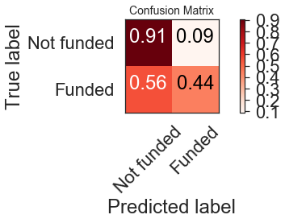

```python
for key, classifier in classifiers.items():
    classifier.fit(X_train, y_train)
    y_pred = classifier.predict(X_test)
    training_score = cross_val_score(classifier, X_train, y_train, cv=5)
    #training_score = f1_score(classifier, X_train, y_train, average='weighted')
    print("Classifiers: ", classifier.__class__.__name__, "Has a training score of", round(training_score.mean(), 2) * 100, "% accuracy score")
    print("-"*80)
    print ("Classification Report: ")
    print (classification_report(y_test, y_pred))
    print ("")
    print ("Accuracy Score: ", accuracy_score(y_test, y_pred))
    print ("")
    print ("Roc-auc score: ", roc_auc_score(y_test, y_pred))
    print ("")

    # Plot confusion matrix
    labels = ['Not funded', 'Funded']
    fig = plt.figure(figsize=(8,4))
    plot_confusion_matrix(confusion_matrix(y_test, y_pred), labels, title="Confusion Matrix", cmap=plt.cm.Reds,normalize=True)
    plt.show()
```

With SVM model, specifc probability of conversion for each offer can be calculated using **predict_proba()** function. The 'probability = True' also needs to be turned on when training the SVC model. An example is shown below:

```python
import random
#train svc model with encoded data
clf = SVC(gamma='scale',cache_size=200,probability = True)
clf.fit(X_train, y_train)

#pick a random observation from test dataset
randomindex = random.randint(0,len(X_test)-1)

#predict the probability
prob = clf.predict_proba([X_test[randomindex]])
print ('The probability for conversion is ' + "{0:.0%}".format(prob[0][1]))
print ('The actual status of the loan offer is ' + str(y_test[randomindex]))
```

[output not shown]

The model predicts the conversion probability for this loan offer attribute to this specific user is 19%, which is quite low. The actual status for this loan offer is also 0, meaning it's not funded. The predicted result is consistent with the actual result.

# V. Conclusion

In this data challenge, I built machine learning models to predict whether a user will accept the loan offer or not based on their click information. The main challenges for this dataset are:

1. Highly imbalanced data set.
2. Very high false negative rate using traditional machine learning models.

If the related marketing team is interesting in finding users who tend not to accept loan offers, simple logistic regression is good enough. However, if they care more about finding users who is very likely loan offers, SVM classifier with autoencoder representations can give reasonably accurate predictions.

Futher model refinement can be:

1. There are some room to further improve random forest model's performance. Fine tuning hyperparameters for random forests is worthwhile trying to see whether the false negative rate can be decreased.
2. Fine tuning hyperparameters and autoencoding part for SVM classifiers.